# Practical Machine Learning Course Project

On the weightlifting exercise classification

Jan Herman

February 10, 2015

## Abstract

In this analysis we aim to classify weightlifting exercises measurements into 5 different classes. Each measurement contains data about one particular unilateral dumbbell biceps curl. The class variable corresponds to the way the exercise was done – class *A* means correctly performed, classes *B*–*E* mean different common mistakes. The dataset is publicly available from http://groupware.les.inf.puc-rio.br/har and described in detail in the original paper (Velloso et al. 2013).

The report consist of four parts – at first we do a little exploratory analysis, then comes the dataset cleaning part. In the third section we describe the prediction model creation and estimate its performance. The last part summarizes the results.

We have chosen predicting by random forests, since it is a powerfull and robust prediction method. Model accuracy estimated by the 10-fold cross validation is 99.5 %.

## Exploratory analysis

At first we load the R-libraries `dplyr`, `caret` and `ggplot2` used in the entire analysis (see Wickham and Francois 2015, Kuhn (2015) and Wickham (2015)). Then we load the dataset and determine the number of measurements and the number of variables.

```r
library(dplyr)
library(caret)
library(ggplot2)

pml <- read.csv("data/pml-training.csv")
dim(pml)
```

```
## [1] 19622   160
```

When we look at the summary of the dataset (see Apendix part), we see that a lot of variables have vast majority of values either blank or NA. Let us count those:

```r
sum(apply(pml, 2, function(x) mean(is.na(x) | x == "")) > .95)
```

```
## [1] 100
```

So 100 out of total 160 variables have more than 95 % blank or NA values.

As these variables carry little information, we discard them from the further analysis.

## Data preparation

At first we remove the beforementioned variables with lots of blank values together with another variables we consider of little use for classification (the variables with timestamps, the ones describing the sliding windows and the variable `X` – the measurement counter).

```r
pml_selected <- pml %>%
    select(which(
        apply(pml, 2, function(x) mean(is.na(x) | x == "")) <= .95)
        ) %>%
    select(-contains("timestamp"), -contains("window"), -X)
```

## Classification models

We have fitted two different classes of models. As a baseline we used one of the simplest classification methods – *k*-Nearest Neighbors (see Wikipedia 2016). Then we tried more complicated models – the Random Forest classificator (see Breiman and Cutler 2015). Both kinds of models were constructed through `caret` package wrapper (see Kuhn 2015).

The accuracies of both classes of models are evaluated by means of 10-fold cross validation. Even though this is available as an automatized process in the `caret` package, we decided to do it “by hand” to be seen clearly what is going on (and what is under the hood of the `caret`).

Let us first divide the training dataset into 10 parts. We will train 10 classificators of each type on 9 dataset parts and evaluate the accuracy on the remaining part. The mean of these accuracies will be our 10-fold cross validation estimation of the final model accuracy.

```r
set.seed(213)

fold_count <- 10
folds <- createFolds(pml_selected$classe, k = fold_count)
```

### *k*-Nearest Neighbors

Now we train the *k*-NN models (with *k* = 10) ten times. Each time we train it on the dataset with one particular fold removed. On this removed fold we later evaluate accuracy of the corresponding model. The final accuracy estimate is the mean of these 10 accuracies.

```r
models_knn <- lapply(1:fold_count,
                    function(i){
                        train(classe ~ .,
                        data = pml_selected[-folds[[i]], ],
                        method = "knn",
                        preProcess = c("center","scale"),
                        tuneGrid = data.frame(k = 10),
                        trControl = trainControl(method = "none"))
                    }
                    )

estimated_accuracies_knn <-
    sapply(1:fold_count,
           function(i){
               mean(predict(models_knn[[i]], newdata = pml_selected[folds[[i]], ]) ==
                        pml_selected$classe[folds[[i]]])
           }
           )


print(mean(estimated_accuracies_knn))
```

```
## [1] 0.9536239
```

Hence we have the baseline accuracy of approximately 95.4 % (pretty good, isnt’t it?). To build a little bit better model, we used Random Forests.

### Random Forests

As before, we train 10 models (each on 9 of 10 folds) and estimate the accuracy on the missing fold.

```r
models_rf <- lapply(1:fold_count,
                    function(i){
                        train(classe ~ .,
                        data = pml_selected[-folds[[i]], ],
                        method = "rf",
                        tuneGrid = data.frame(mtry = ncol(pml_selected) %/% 2),
                        trControl = trainControl(method = "none"))
                    }
                    )

estimated_accuracies_rf <-
    sapply(1:fold_count,
           function(i){
               mean(predict(models_rf[[i]], newdata = pml_selected[folds[[i]], ]) ==
                        pml_selected$classe[folds[[i]]])
           }
           )

print(mean(estimated_accuracies_rf))
```

```
## [1] 0.9952605
```

That means we achieved an accuracy estimate of (kind of unbelievable) 99.5 %!

Let us look on the accuracy in more detail. At first a figure of the confusion matrix:

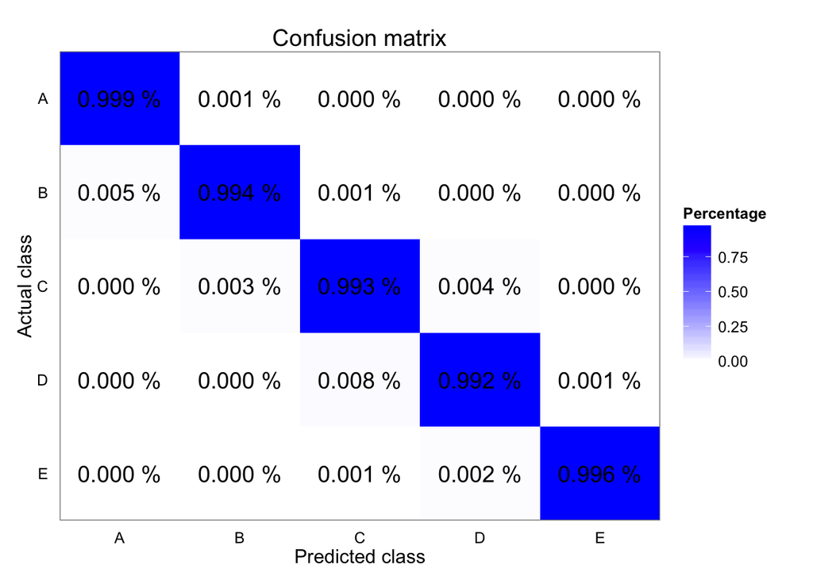

```r
predictions <- factor(rep_len(c("A", "B", "C", "D", "E"), nrow(pml_selected)))
for (i in 1:fold_count){
    predictions[folds[[i]]] <-
        predict(models_rf[[i]], newdata = pml_selected[folds[[i]], ])
}

single_freq <- as.data.frame(table(pml_selected$classe))
frequencies <- as.data.frame(table(pml_selected$classe, predictions))
plot_data <- inner_join(single_freq, frequencies, by = c("Var1" = "Var1")) %>%
    mutate(Percentage = Freq.y / Freq.x)
ggplot(data = plot_data,
       aes(x = predictions, y = factor(Var1, levels(predictions)[5:1]), fill = Percentage)) +
    geom_tile() +
    scale_fill_gradient2(low = "white", high = "blue") +
    geom_text(aes(label = sprintf("%.3f %%", Percentage)), colour="black") +
    theme_bw() +
    theme(axis.ticks.x = element_blank(), axis.ticks.y = element_blank()) +
    scale_x_discrete(expand = c(0, 0)) +
    scale_y_discrete(expand = c(0, 0)) +
    labs(title = "Confusion matrix", y = "Actual class",
         x = "Predicted class", fill = "Percentage")
```

More detailed summary of the model accuracy can be seen in Appendix section.

## Conclusion

We have built *k*-NN and random forest prediction models that predict the way how the exercise was done. The overall estimated accuracy of the random forest predictor was 99.5 %.

## Appendix

### Test data prediction

```r
pml_t <- read.csv("data/pml-testing.csv")

pml_selected_t <- pml_t %>%
    select(which(
        apply(pml, 2, function(x) mean(is.na(x) | x == "")) <= .95)
    ) %>%
    select(-contains("timestamp"), -contains("window"), -X)

predictions_t <- sapply(1:fold_count,
                        function(i){
                            predict(models_rf[[i]], newdata = pml_selected_t)
                        }
                        )

prediction_t <- apply(predictions_t,
                      1,
                      function(x){names(which.max(table(x)))})
#prediction_t
```

Basic summary of the data (mentioned in the Exploratory analysis section):

```r
summary(pml)
```

```
##        X            user_name    raw_timestamp_part_1 raw_timestamp_part_2
##  Min.   :    1   adelmo  :3892   Min.   :1.322e+09    Min.   :   294
##  1st Qu.: 4906   carlitos:3112   1st Qu.:1.323e+09    1st Qu.:252912
##  Median : 9812   eurico  :3070   Median :1.323e+09    Median :496380
##  Mean   : 9812   charles :3536   Mean   :1.323e+09    Mean   :500656
##  3rd Qu.:14717   jeremy  :3402   3rd Qu.:1.323e+09    3rd Qu.:751891
##  Max.   :19622   pedro   :2610   Max.   :1.323e+09    Max.   :998801
##
##           cvtd_timestamp  new_window    num_window      roll_belt
##  28/11/2011 14:14: 1498   no :19216   Min.   :  1.0   Min.   :-28.90
##  05/12/2011 11:24: 1497   yes:  406   1st Qu.:222.0   1st Qu.:  1.10
##  30/11/2011 17:11: 1440               Median :424.0   Median :113.00
##  05/12/2011 11:25: 1425               Mean   :430.6   Mean   : 64.41
##  02/12/2011 14:57: 1380               3rd Qu.:644.0   3rd Qu.:123.00
##  02/12/2011 13:34: 1375               Max.   :864.0   Max.   :162.00
##  (Other)         :11007
##    pitch_belt          yaw_belt       total_accel_belt kurtosis_roll_belt
##  Min.   :-55.8000   Min.   :-180.00   Min.   : 0.00             :19216
##  1st Qu.:  1.7600   1st Qu.: -88.30   1st Qu.: 3.00    #DIV/0!  :   10
##  Median :  5.2800   Median : -13.00   Median :17.00    -1.908453:    2
##  Mean   :  0.3053   Mean   : -11.21   Mean   :11.31    -0.016850:    1
##  3rd Qu.: 14.9000   3rd Qu.:  12.90   3rd Qu.:18.00    -0.021024:    1
##  Max.   : 60.3000   Max.   : 179.00   Max.   :29.00    -0.025513:    1
##                                                        (Other)  :  391
##  kurtosis_picth_belt kurtosis_yaw_belt skewness_roll_belt
##           :19216            :19216              :19216
##  #DIV/0!  :   32     #DIV/0!:  406     #DIV/0!  :    9
##  47.000000:    4                       0.000000 :    4
##  -0.150950:    3                       0.422463 :    2
##  -0.684748:    3                       -0.003095:    1
##  -1.750749:    3                       -0.010002:    1
##  (Other)  :  361                       (Other)  :  389
##  skewness_roll_belt.1 skewness_yaw_belt max_roll_belt     max_picth_belt
##           :19216             :19216     Min.   :-94.300   Min.   : 3.00
##  #DIV/0!  :   32      #DIV/0!:  406     1st Qu.:-88.000   1st Qu.: 5.00
##  0.000000 :    4                        Median : -5.100   Median :18.00
##  -2.156553:    3                        Mean   : -6.667   Mean   :12.92
##  -3.072669:    3                        3rd Qu.: 18.500   3rd Qu.:19.00
##  -6.324555:    3                        Max.   :180.000   Max.   :30.00
##  (Other)  :  361                        NA's   :19216     NA's   :19216
```

[output cut: 313 more lines]

```
##  Min.   :-446.00   Min.   :-1280.0   Min.   :-896.0   Min.   :-973.0
##  1st Qu.:-182.00   1st Qu.: -616.0   1st Qu.:   2.0   1st Qu.: 191.0
##  Median : -39.00   Median : -378.0   Median : 591.0   Median : 511.0
##  Mean   : -55.29   Mean   : -312.6   Mean   : 380.1   Mean   : 393.6
##  3rd Qu.:  26.00   3rd Qu.:  -73.0   3rd Qu.: 737.0   3rd Qu.: 653.0
##  Max.   : 291.00   Max.   :  672.0   Max.   :1480.0   Max.   :1090.0
##
##  classe
##  A:5580
##  B:3797
##  C:3422
##  D:3216
##  E:3607
##
##
```

Detailed model accuracy and other related statistics:

```r
confusionMatrix(predictions, pml_selected$classe)
```

```
## Confusion Matrix and Statistics
##
##           Reference
## Prediction    A    B    C    D    E
##          A 5575   20    0    0    0
##          B    3 3773   11    0    1
##          C    0    4 3399   25    5
##          D    0    0   12 3189    8
##          E    2    0    0    2 3593
##
## Overall Statistics
##
##                Accuracy : 0.9953
##                  95% CI : (0.9942, 0.9962)
##     No Information Rate : 0.2844
##     P-Value [Acc > NIR] : < 2.2e-16
##
##                   Kappa : 0.994
##  Mcnemar's Test P-Value : NA
##
## Statistics by Class:
##
##                      Class: A Class: B Class: C Class: D Class: E
## Sensitivity            0.9991   0.9937   0.9933   0.9916   0.9961
## Specificity            0.9986   0.9991   0.9979   0.9988   0.9998
## Pos Pred Value         0.9964   0.9960   0.9901   0.9938   0.9989
## Neg Pred Value         0.9996   0.9985   0.9986   0.9984   0.9991
## Prevalence             0.2844   0.1935   0.1744   0.1639   0.1838
## Detection Rate         0.2841   0.1923   0.1732   0.1625   0.1831
## Detection Prevalence   0.2851   0.1930   0.1750   0.1635   0.1833
## Balanced Accuracy      0.9988   0.9964   0.9956   0.9952   0.9979
```

## Notice

This report was done as a Course Project to Practical Machine Learning class on coursera.org and is available on [github](http://hermitko.github.io/PML_CourseProject/).

References

Breiman, Leo, and Adele Cutler. 2015. “Random Forests.” https://www.stat.berkeley.edu/~breiman/RandomForests/.

Kuhn, Max et al. 2015. “The Caret Package.” http://topepo.github.io/caret/index.html.

Velloso, Eduardo, Andreas Bulling, Hans Gellersen, Wallace Ugulino, and Hugo Fuks. 2013. “Qualitative Activity Recognition of Weight Lifting Exercises.” In *Proceedings of the 4th Augmented Human International Conference*, 116–23. ACM. http://groupware.les.inf.puc-rio.br/public/papers/2013.Velloso.QAR-WLE.pdf.

Wickham, Hadley. 2015. “Ggplot2.” *Ggplot2.org*. http://ggplot2.org/.

Wickham, Hadley, and Romain Francois. 2015. “A Grammar of Data Manipulation.” *Cran.r-Project.org*. https://cran.r-project.org/web/packages/dplyr/index.html.

Wikipedia. 2016. “K-Nearest Neighbors Algorithm.” https://en.wikipedia.org/wiki/K-nearest_neighbors_algorithm.